# Rプログラミング入門 応用2：複雑データの処理（繰り返し）

Cho（ztempest0218@gmail.com）

Last Updated: 2026-07-06

**今回の内容**

- 繰り返し処理（ループ）の考え方と `for` の書き方
- 都道府県47個のデータを読み込んで、1つにまとめる
- 地域ごとに、同じ分析を繰り返す

**今回使用するデータ**

- pref_split.zip（47個のCSVファイル）

SSDSE（教育用標準データセット）の授業用小サンプル（2018〜2023年、47都道府県、282行）を、都道府県ごとに47個のCSVファイルへ分割したものである。解凍して使ってください。

まず、今回使用するパッケージと日本語フォントを読み込んでおく。

```r
rm(list = ls())

library(tidyverse)
library(showtext)

# 日本語フォント
font_add_google("Noto Serif JP", "notojp")
showtext_auto()
```

# 1 繰り返し処理とは

第12回までで、データの読み込み・前処理・結合・可視化・回帰分析という、データ分析の一通りの流れを学んできた。1〜２個のデータを分析することは、もう十分にできるはずである。

しかし実際の分析では、同じ処理を、対象だけ変えながら何度も繰り返す場面が頻繁に生じる。都道府県ごとに分かれた47個のファイルを順に読み込んで結合する、地域ごとに同じ分析を繰り返す、といった作業である。いずれも処理の中身は共通しており、対象だけが入れ替わっていく。文面を変えずに宛名だけ差し替えて年賀状を書き続けるのと、構造は同じである。

こうした処理を、コードをコピー＆ペーストで47回書くのは現実的ではない。記述に手間がかかるうえ、後から一箇所を修正するたびに47箇所すべてを直すことになり、修正漏れやミスを生みやすい。プログラミングには **DRY 原則**（Don’t Repeat Yourself、同じ記述を繰り返すな）という考え方があり、同じコードを並べるのではなく、「繰り返す」という構造そのものを一度だけ書くのが定石とされる。

この繰り返しをコンピュータに指示する仕組みが、**繰り返し処理（ループ）**である。ループとは、**対象のリストから中身を1つずつ取り出し、そのたびに同じ処理をくり返す**仕組みにほかならない（下図）。

[figure not shown]

次の章から、その書き方を学んでいく。

その前に、Rでよく使う繰り返しの関数を整理しておく。

| 場面 | 関数 | この授業での扱い |
| --- | --- | --- |
| 何回くり返すか分かっている | `for` | ◎ 今回の中心 |
| 何回で終わるか分からない | `while` | ○ 補助 |
| `for` を短く書きたい（base R） | `sapply()`・`lapply()` | △ 参考 |
| `for` を短く書きたい（tidyverse） | `purrr::map()` 系 | △ 参考 |

この授業では、最も基本的で汎用性の高い **`for`** を中心に扱う。`while` は回数が事前に読めないときに使う。apply系や `purrr` は、`for` に慣れた後の発展として位置づける。

また、ループの流れを途中で変える命令として、**`break`**（ループ全体を打ち切る）と **`next`**（その回だけ飛ばして次へ進む）がある。詳しくは後で扱うが、動きのイメージを図で確認しておく。

[figure not shown]

# 2 `for` ループの書き方

## 2.1 まずはループを動かしてみる

まず、次の3行をR Scriptに書いて、実行してみてほしい。

```r
for (i in 1:5) {
  print(i)
}
```

```
## [1] 1
## [1] 2
## [1] 3
## [1] 4
## [1] 5
```

`1` から `5` までの数字が、順番に表示された。このコードを日本語に訳すと、次のようになる。

> **「`i` を `1, 2, 3, 4, 5` と順番に変えながら、そのたびに `{ }` の中を実行しなさい」**

つまり、コンピュータの中では次のことが起きている。

1. `i` に `1` を入れて、`print(i)` を実行する → `1` が表示される
2. `i` に `2` を入れて、`print(i)` を実行する → `2` が表示される
3. …これを `5` まで繰り返して、終了する

`for` ループの基本形は、次の通りである。

```r
for (繰り返し変数 in 繰り返しリスト) {
  # 繰り返したい処理
}
```

`for` では、2種類のかっこを使い分ける。**丸かっこ `( )` には「くり返しの設定」**（何を・どの順に取り出すか）を、**波かっこ `{ }` には「毎回くり返したい処理」**を書く。

この基本形は、3つの部分からできている。**「繰り返しリスト」から中身を1つずつ「繰り返し変数」に入れ、そのたびに「`{ }` の中」を実行する**、という流れになっている。

| 部分 | 役割 | 上の例では |
| --- | --- | --- |
| 繰り返しリスト | くり返しの元になるベクトル。先頭から中身を1つずつ取り出す | `1:5`（= `1,2,3,4,5`） |
| 繰り返し変数 | 取り出した中身が毎回入る変数（名前は自由。`i` が定番） | `i`（1回目は `1`、2回目は `2`…） |
| `{ }` の中 | 中身を取り出すたびに実行する処理 | `print(i)` |

## 2.2 数字でなくてもよい

「繰り返しリスト」は、数字である必要はない。第3回で作った都道府県名のような**文字列のベクトル**でもよい。

```r
prefs <- c("東京都", "大阪府", "愛知県")

for (p in prefs) {
  print(p)
}
```

```
## [1] "東京都"
## [1] "大阪府"
## [1] "愛知県"
```

ここでは、繰り返し変数 `p` に `"東京都"` → `"大阪府"` → `"愛知県"` が順番に入り、そのたびに `print()` で表示している。最初の例（`print(i)`）とまったく同じで、表示する中身が数字から都道府県名に変わっただけである。

なお、繰り返し変数の名前（`for (◯◯ in ...)` の `◯◯`）は自由に決めてよい。慣例として、`1, 2, 3` のような**番号**を取り出すときは `i`（index の頭文字）を使い、`prefs` のようなベクトルから中身を1つずつ取り出すときは、その頭文字をとって `p` のように**短い名前**をつけることが多い。こうすると、ベクトル（`prefs`）と、そこから取り出した中身（`p`）が一目で見分けられる。名前が違うだけで、仕組みは `for (i in 1:5)` とまったく同じである。

この小さな例が、実は今回の授業のすべてである。あとで行う「地域ごとの分析」も、`print()` で表示する代わりに、`{ }` の中で `filter()` や `lm()` などを実行するだけで、構造はこれとまったく同じである。

## 2.3 結果をオブジェクトに保存する

`print()` で画面に表示するだけなら簡単だが、実際の分析では、**ループで計算した結果を、あとで使えるようにオブジェクトへ保存**したいことがほとんどである。

このとき、結果を格納するオブジェクト（ここでは数値ベクトル）を、ループの前にあらかじめ用意しておくのがコツである。これを**事前確保**（pre-allocation）という。

```r
# 結果を格納するオブジェクト（0が5個のベクトル）を先に用意する
result <- numeric(5)

for (i in 1:5) {
  result[i] <- i^2     # i番目の要素に、iの2乗を代入する
}

result
```

```
## [1]  1  4  9 16 25
```

`numeric(5)` は、`0` が5個並んだ数値ベクトルを生成する。ループの中では、`result[i]`（`result` の `i` 番目の要素）に計算結果を1つずつ代入していく。第3回で学んだ `object[i]`（i番目の要素を指定する書き方）が、ここで活きてくる。

処理の流れは次の通りである。

1. 長さ5のベクトル `result` を用意する（中身はすべて `0`）
2. `i = 1`：`1` の2乗（= 1）を `result[1]` に代入する
3. `i = 2`：`2` の2乗（= 4）を `result[2]` に代入する
4. …`i = 5` まで繰り返すと、`result` のすべての要素が埋まる

**「結果を格納するオブジェクトを先に用意し、ループで1要素ずつ代入する」**。この型を押さえておけば、ループで結果を保存する場面で困ることはほとんどない。

## 2.4 ループを書かなくてもよい場合

ここまで `for` の書き方を見てきたが、最後に1つ大事なことを伝えておく。**Rでは、単純な計算にループは不要である。**

例えば、「ベクトルの全要素を2乗したい」とする。第3回で学んだように、Rはベクトルにそのまま演算できるため、ループを書かずに1行で済む。

```r
x <- 1:5

x^2
```

```
## [1]  1  4  9 16 25
```

要素を1つずつ取り出して、ループで2乗することもできるが、`x^2` の方が短く、速く、間違えにくい。`log(x)` や `sum(x)`、第6回で学んだ `group_by()` + `summarise()` によるグループ集計も同じで、ループを書く必要はない。

では、ループはいつ使うのか。目安は次の通りである。

| 目的 | ループは必要？ |
| --- | --- |
| ベクトルの計算（2乗、対数、合計など） | 不要（`x^2` などでよい） |
| グループごとの平均・合計 | 不要（`group_by()` + `summarise()` でよい） |
| グループごとに**回帰分析**を繰り返す | **ループを使う**（`group_by()` 系の発展的な書き方もある） |
| **複数のファイル**を次々に読み込む | **ループを使う** |

つまり、「計算そのもの」はRに任せられるが、**分析やファイル処理のような「作業」を何度も繰り返すときにループを使う**。この2つの場面は、後半で実際に体験する。

# 3 `while` ループ

`for` が「決まった回数」繰り返すのに対し、**`while` は「条件が成り立っている間」繰り返し続ける**。両者の本質的な違いは、**繰り返す回数を、始める前から知っているかどうか**にある。回数が分かっていれば `for`、分かっていなければ `while` を使う。

まず、`for` と同じことを `while` で書いてみる。

```r
i <- 1

while (i <= 5) {
  print(i)
  i <- i + 1
}
```

```
## [1] 1
## [1] 2
## [1] 3
## [1] 4
## [1] 5
```

`i` が5以下である間、`{ }` の中を実行し続ける。ただし、これは回数（5回）が分かっているので、本来は `for` で十分である。`while` の真価は、次のような「回数が事前に読めない」場面で発揮される。

## 3.1 目標に達するまで繰り返す

年利3%で運用したとき、元本が2倍になるまで何年かかるかを考える。何年かかるかは、計算してみるまで分からない。そこで、「元本が目標額に届いていない間」ループを続ける。

```r
money <- 100    # 元本
goal  <- 200    # 目標（2倍）
year  <- 0

while (money < goal) {
  money <- money * 1.03   # 1年で3%増える
  year  <- year + 1
}

year    # 2倍になるまでにかかった年数
```

```
## [1] 24
```

`24` と表示される。年利3%なら、元本が2倍になるまで約24年かかるということである。回数（24）を知らなくても、「条件（`money < goal`）が成り立つ間」と書くだけで、Rが必要な回数だけ自動的に繰り返してくれる。回数を先に指定しなければならない `for` には、これはできない。

## 3.2 条件を満たすまで繰り返す（シミュレーション）

もう1つ、繰り返す回数がその場のランダムで決まる例を見る。サイコロを振り、`6` が出るまで振り続ける。何回で出るかは、やってみるまで分からない。

```r
set.seed(123)
dice  <- 0
count <- 0

while (dice != 6) {
  dice  <- sample(1:6, 1)   # サイコロを1回振る
  count <- count + 1
}

count   # 6が出るまでに振った回数
```

```
## [1] 2
```

`!=` は「等しくない」という意味で、`dice != 6` は「`6` 以外」を表す。`6` が出た瞬間に条件が `FALSE` になり、ループが止まる。このように、繰り返す回数を事前に決められない処理は `while` の得意分野であり、乱数を使ったシミュレーションでもよく用いられる。

## 3.3 無限ループと `break`

`while` の最大の落とし穴は、**条件がいつまでも `FALSE` にならないと、プログラムが永遠に止まらなくなる**ことである（無限ループ）。たとえば、先ほどの例で `money` を増やす1行を書き忘れると、条件 `money < goal` が永遠に `TRUE` のまま、ループが止まらなくなる。

```r
# 【実行しないこと】money を更新していないので、永遠に止まらない
money <- 100
goal  <- 200
year  <- 0

while (money < goal) {
  year <- year + 1     # ← money <- money * 1.03 を書き忘れている！
}
```

もし実行して止まらなくなったら、あわてずコンソールで `Esc` キー（RStudioの停止ボタン）を押して強制停止すればよい。

[figure not shown]

無限ループに陥ったConsole。右上の赤い停止ボタンで強制停止できる

こうしたミスへの保険が、**`break`** である。`break` は**実行した瞬間にループを打ち切る**命令であり、条件分岐の `if`（もし〜なら）と組み合わせて、繰り返しの上限を決めておく。

```r
money <- 100
goal  <- 200
year  <- 0

while (money < goal) {
  # money <- money * 1.03 を書き忘れたまま実行しても…
  year <- year + 1

  if (year >= 1000) {   # 1000回に達したら、強制的に打ち切る
    break
  }
}

year
```

```
## [1] 1000
```

`money` を増やし忘れたままでも、1000回に達した時点で `break` が実行され、ループは安全に止まる。実務で `while` を使うときは、このように**上限回数の保険をかけておく**と安心である。

## 3.4 その回だけ飛ばす：`next`

`break` がループ全体を打ち切るのに対し、**`next` はその回だけを飛ばして、次の繰り返しへ進む**。よくあるのは、欠損値 `NA` を含むデータの処理である。

例えば、「20より大きい値だけを表示する」ループを考える。データに `NA` が混ざっていると、`if` の条件判定に `NA` が入った時点でエラーが発生し、**ループはそこで止まってしまう**。そこで、`is.na()`（欠損値かどうかを判定する関数）と `next` を組み合わせて、`NA` の回だけ飛ばす。

```r
x <- c(10, 25, NA, 40)

for (i in 1:4) {
  if (is.na(x[i])) {
    next              # 欠損値なら、この回は飛ばして次へ
  }
  if (x[i] > 20) {
    print(x[i])
  }
}
```

```
## [1] 25
## [1] 40
```

`NA` を安全に飛ばして、最後の `40` まで処理できた。試しに `is.na()` の2行を外して実行すると、3番目の `NA` のところでエラーが出て、ループが途中で止まることを確認できる。実際のデータには欠損値がつきものであり、この「`is.na()` + `next`」は、ループを最後まで走り切らせるための定番の型である。`next` は `for` でも `while` でも使える。

この授業のデータ処理では、繰り返す回数はたいてい分かっている（47都道府県、複数のファイル…）ため、**基本は `for` で足りる**。`while` は「回数が事前に読めない繰り返し」のための道具として押さえておけばよい。

# 4 `for` を短く書く：`sapply()` と `map()`

Rには、**`for` と同じことをより短く書くための関数**として、base R の `sapply()`・`lapply()` と、tidyverse の `map()` 系がある。他人のコードやAIが生成したコードに頻繁に登場するため、簡単に紹介しておく。

前半で書いた「1から5までの2乗」のループは、base R の `sapply()` を使うと1行で書ける。

```r
sapply(1:5, function(x) x^2)
```

```
## [1]  1  4  9 16 25
```

`sapply(リスト, 関数)` は、**リストの各要素に同じ関数を適用し、結果をベクトルにまとめて返す**。オブジェクトの事前確保も、`result[i]` への代入も、`sapply()` が内部で行ってくれる。兄弟分の `lapply()` は、結果をベクトルではなく list で返す（`l` は list、`s` は simplify の頭文字である）。

tidyverse 版が、`purrr` パッケージの `map()` 系である。使い方は `sapply()` とほぼ同じである。

```r
library(purrr)

map_dbl(1:5, function(x) x^2)
```

```
## [1]  1  4  9 16 25
```

`map_dbl()` は「結果を数値（double）のベクトルで返す `map()`」である。返り値の型ごとに `map_chr()`（文字列）、`map_dfr()`（データフレーム）などの変種がある。

なお、`sapply()` や `map()` が短縮できるのは **`for` だけ**である。どちらも「リストの各要素に適用する」関数であるため、リストの長さ＝繰り返し回数が事前に決まっている必要がある。回数が事前に読めない `while` に、短縮形は存在しない。

ちなみに、`map()` のような関数はどの言語にもあるわけではない。第3回で紹介した手続型言語の C や Fortran には `map()` に相当する関数がなく、繰り返しはすべて `for` で手書きする。逆に言えば、**`for` さえ書ければ、どの言語でも繰り返しを表現できる**。`for` を「最も基本的で汎用性が高い」と位置づけたのは、この意味である。

繰り返しになるが、まず `for` を自分の手で書けるようになることが先である。仕組みを理解しないまま短縮形だけを覚えると、エラーが出たときに自力で直せない。`for` に十分慣れて、コードが長いと感じるようになったころに使い始めればよい。

# 5 都道府県47個のデータを読み込んで1つにまとめる

実際のデータ分析では、対象となるデータが最初から1つにまとまっていることは少ない。地域ごと・年ごとに別々のファイルへ分かれていることが多く、e-Statや自治体のサイトからダウンロードすると、「東京都.csv」「大阪府.csv」…のように47個のファイルに分かれている、という状況にしばしば出会う。これらを1つずつ手で開いて結合するのは、手間がかかるうえミスも生じやすい。まずは、この散らばったファイルをループで1つの表にまとめる作業から始める。

今回は、この状況を再現するため、授業用SSDSEデータを都道府県ごとに分割した**47個のCSVファイル**を配布する。[Rプログラミング入門授業用サイト](https://ztempest0218.github.io/R-Programming/)からダウンロードしてください。

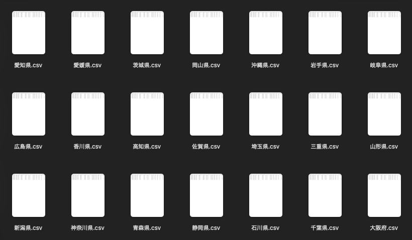

都道府県ごとに分かれた47個のCSVファイル

## 5.1 ループで47ファイルを読み込んで結合する

配布した47個のCSVファイル（`./data/pref_split` に保存されているとする）を、ループで1つずつ読み込み、第7回で学んだ `bind_rows()` で縦に積み重ねていく。

```r
# working directory は各自の環境に応じて設定すること

# フォルダ内のCSVファイルの一覧（パス）を取得する
files <- list.files(
  "./data/pref_split",
  pattern = "\\.csv$",     # 「.csvで終わるファイル」だけを選ぶ
  full.names = TRUE        # フォルダ名を含む完全なパスで返す
)

length(files)
```

```
## [1] 47
```

```r
# 空のdfを用意する
combined <- data.frame()

# 1ファイルずつ読み込んで、下に積み重ねる
for (f in files) {
  d <- read.csv(f, fileEncoding = "UTF-8")
  combined <- bind_rows(combined, d)
}

dim(combined)
```

```
## [1] 282  34
```

`list.files()` は、フォルダの中にあるファイル名を一覧で取ってくる関数である。あとはループで、1ファイルずつ `read.csv()` で読み込み、`bind_rows()` で下に積み重ねているだけである。282行（= 47都道府県 × 6年）のデータが、1つの表にまとまったことが確認できる。

この**「`list.files()` でファイル一覧を作り、ループで1つずつ読み込んで結合する」**という型は、実務で最も頻繁に使うループである。ファイルが47個でも470個でも、書くコードはまったく同じである。卒論でe-Statから大量のファイルをダウンロードしたときに、必ず役に立つ。実際の作業では、47個のrawデータを読み込んで、前処理した47個の中間ファイルを書き出し、最終的に結合することが多い。

# 6 地域ごとに分析を繰り返す

データがそろったところで、今度は地域ごとに同じ分析を繰り返す。ここで知りたいのは、**「保育所等の定員と出生率の関係は、地域によってどう違うのか」**である。

## 6.1 都道府県を8つの地域に分類する

まず、47都道府県を8つの地域に分類する。

```r
combined <- combined %>%
  mutate(
    region = case_when(
      prefecture %in% c("北海道") ~ "北海道",
      prefecture %in% c("青森県", "岩手県", "宮城県", "秋田県", "山形県", "福島県") ~ "東北",
      prefecture %in% c("茨城県", "栃木県", "群馬県", "埼玉県", "千葉県", "東京都", "神奈川県") ~ "関東",
      prefecture %in% c("新潟県", "富山県", "石川県", "福井県", "山梨県", "長野県", "岐阜県", "静岡県", "愛知県") ~ "中部",
      prefecture %in% c("三重県", "滋賀県", "京都府", "大阪府", "兵庫県", "奈良県", "和歌山県") ~ "近畿",
      prefecture %in% c("鳥取県", "島根県", "岡山県", "広島県", "山口県") ~ "中国",
      prefecture %in% c("徳島県", "香川県", "愛媛県", "高知県") ~ "四国",
      prefecture %in% c("福岡県", "佐賀県", "長崎県", "熊本県", "大分県", "宮崎県", "鹿児島県", "沖縄県") ~ "九州・沖縄",
      TRUE ~ "その他"
    )
  )

count(combined, region)
```

| region | n |
| --- | --- |
| 中国 | 30 |
| 中部 | 54 |
| 九州・沖縄 | 48 |
| 北海道 | 6 |
| 四国 | 24 |
| 東北 | 36 |
| 近畿 | 42 |
| 関東 | 42 |

## 6.2 地域ごとに回帰を実行する

使う変数は、保育所等の定員（`nursery_capacity`）と合計特殊出生率（`total_fertility_rate`）である。定員はそのままでは人口の多い都道府県ほど大きくなるため、人口千人あたりの定員（率変数）に直したうえで、係数を「%」で解釈できるように対数をとる（第11回）。

```r
combined <- combined %>%
  mutate(
    nursery_per_1000 = nursery_capacity / population * 1000,
    log_nursery = log(nursery_per_1000)
  )
```

ある1つの地域について、合計特殊出生率を千人あたり定員の対数に回帰すると、

$$\text{tfr}_i = \beta_0 + \beta_1 \, \log(\text{nursery}_i) + u_i$$

傾き $\beta_1$ は「千人あたり保育所定員が1%増えると、合計特殊出生率が平均的に約 $\beta_1 / 100$ 単位変化する」ことを表す（第11回で学んだ対数の読み方）。保育所等の定員が充実している地域ほど、子育てと仕事を両立しやすく、出生率が高いという仮説である。

1つの地域についての推定は、`lm()` を1回実行するだけでよい。これを8つの地域について繰り返す。手順は、前半で学んだ「結果を格納するオブジェクトを先に用意し、ループで1要素ずつ代入する」という型と同じである。

```r
# 地域名の一覧を取り出す（8個）
regions <- unique(combined$region)
n <- length(regions)

# 結果（傾き・標準誤差・p値）を格納するベクトルを先に用意する（各8要素）
slope <- numeric(n)
se    <- numeric(n)
p     <- numeric(n)

# 8回繰り返す
for (i in 1:n) {
  # ① i番目の地域のデータだけを取り出す
  d <- combined %>%
    filter(region == regions[i])

  # ② その地域のデータで回帰分析する
  model <- lm(total_fertility_rate ~ log_nursery, data = d)

  # ③ 傾き・標準誤差・p値を取り出して、i番目の要素に代入する
  slope[i] <- coef(model)[["log_nursery"]]
  se[i]    <- summary(model)$coefficients["log_nursery", "Std. Error"]
  p[i]     <- summary(model)$coefficients["log_nursery", "Pr(>|t|)"]
}

# 1つの表にまとめ、p値に応じた星をつける
result <- data.frame(
  region = regions,
  slope = slope,
  se = se,
  p = p
) %>%
  mutate(
    stars = case_when(
      p < 0.01 ~ "***",
      p < 0.05 ~ "**",
      p < 0.1  ~ "*",
      TRUE     ~ ""
    )
  )

result
```

| region | slope | se | p | stars |
| --- | --- | --- | --- | --- |
| 中部 | 0.16184453 | 0.04373486 | 5.201696e-04 | *** |
| 四国 | 0.01751190 | 0.06085575 | 7.762232e-01 |  |
| 関東 | 0.09982196 | 0.11076073 | 3.728556e-01 |  |
| 中国 | 0.27006723 | 0.06296488 | 1.926738e-04 | *** |
| 九州・沖縄 | 0.46020402 | 0.06272089 | 2.848795e-09 | *** |
| 東北 | 0.14360281 | 0.07819772 | 7.505412e-02 | * |
| 近畿 | 0.25456146 | 0.06578605 | 3.930475e-04 | *** |
| 北海道 | 0.34125822 | 0.34706183 | 3.811404e-01 |  |

ループの中身は、①〜③の3ステップだけである。

1. `filter()` で、`i` 番目の地域のデータだけを取り出す
2. そのデータで `lm()` 線形回帰を実行する
3. 傾き・標準誤差・p値を取り出して、`slope[i]`・`se[i]`・`p[i]`（`i` 番目の要素）に代入する

`coef(model)[["log_nursery"]]` は、回帰の結果 `model` から `log_nursery` の係数（傾き）を数字として取り出す書き方である。`summary(model)$coefficients` は、第11回で見た係数表（Estimate、Std. Error、Pr(>|t|)…）を行列として返すので、行と列の名前を指定して標準誤差やp値を取り出している。いずれも、第3回で学んだ「オブジェクトの中身を名前で取り出す」操作と同じ考え方である。星は `case_when()` でp値から作っており、`***` は1%、`**` は5%、`*` は10%水準で統計的に有意であることを表す。

つまり、このループは、**すでに学んだ関数を `{ }` の中に並べただけ**である。ループ自体に新しい分析手法は何もない。

`arrange()` で傾きの大きい順に並び替えて、結果を確認する。

```r
result %>%
  arrange(desc(slope))
```

| region | slope | se | p | stars |
| --- | --- | --- | --- | --- |
| 九州・沖縄 | 0.46020402 | 0.06272089 | 2.848795e-09 | *** |
| 北海道 | 0.34125822 | 0.34706183 | 3.811404e-01 |  |
| 中国 | 0.27006723 | 0.06296488 | 1.926738e-04 | *** |
| 近畿 | 0.25456146 | 0.06578605 | 3.930475e-04 | *** |
| 中部 | 0.16184453 | 0.04373486 | 5.201696e-04 | *** |
| 東北 | 0.14360281 | 0.07819772 | 7.505412e-02 | * |
| 関東 | 0.09982196 | 0.11076073 | 3.728556e-01 |  |
| 四国 | 0.01751190 | 0.06085575 | 7.762232e-01 |  |

中部・近畿・中国・九州・沖縄では1%水準、東北では10%水準で傾きが有意にプラスであり、**保育所等の定員が多い都道府県ほど出生率が高い**という関係が確認できる（九州・沖縄の0.46は、定員が1%増えると出生率が約0.005高いことに対応する）。一方、北海道は傾きが大きめでも標準誤差が大きく有意ではなく、四国では傾きはほぼ0である。ただし、この係数を因果効果として読むことはできない（第11回）。出生が多い地域ほど保育所が整備される、という逆方向の関係もありうるからである。

なお、繰り返しの対象を変えれば、同じコードがそのまま使い回せる。このように「グループに**分割**し、同じ処理を**適用**し、結果を**結合**する」流れは、split-apply-combine と呼ばれるデータ分析の定番の型である。

## 6.3 補足：`filter()` を使わない書き方

`lm()` には、Stata の `if` に相当する **`subset`** という引数がある。これを使うと、`filter()` でデータを取り出す手順を省略して、次のように書ける。

```r
slope2 <- numeric(n)

for (i in 1:n) {
  model <- lm(total_fertility_rate ~ log_nursery,
              data   = combined,
              subset = region == regions[i])   # ループ変数がそのまま条件に入る

  slope2[i] <- coef(model)[["log_nursery"]]
}

# filter() で計算した slope と一致することを確認
all.equal(slope, slope2)
```

```
## [1] TRUE
```

結果は `filter()` 版とまったく同じである。`subset` 引数は `lm()` のほか、`boxplot()` や `aggregate()` など式（formula）を受け取る関数で広く使える。ただし、`filter()` で取り出したデータは、その後の確認や集計など何にでも使い回せるため、本講義では `filter()` 版を基本とする。

# 7 課題

HW6の〆切は2026年7月15日16:30までです。下記リンクで受領してください。

HW6 https://classroom.github.com/a/XdQYV5kk

また、第9回で出題した**データ可視化レポート**（〆切 7月25日 23:59）も、並行して進めておいてください。